# Dairy of a Pumping Mom

#### … who stopped after 7 months.

##### Comparing supply in the morning and at night:

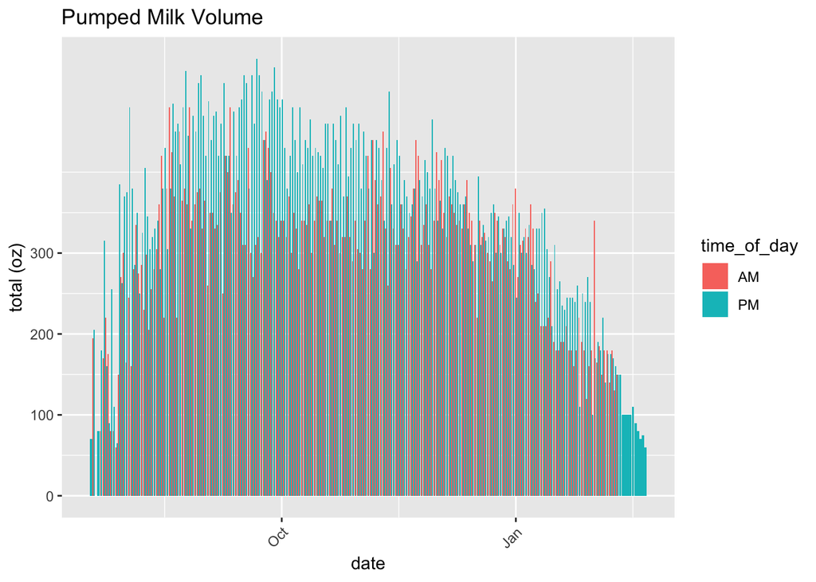

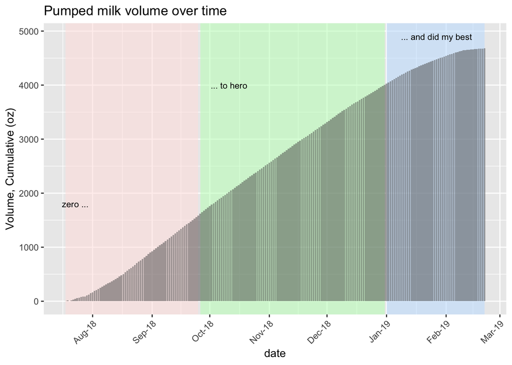

##### Not a great producer, but trying to meet the baby’s needs:

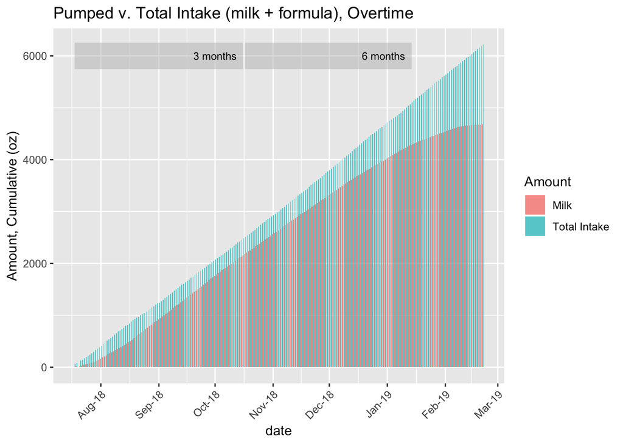

##### Just how much milk was pumped? This is one way to compare:

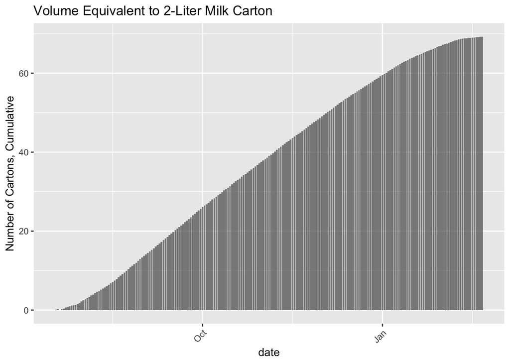

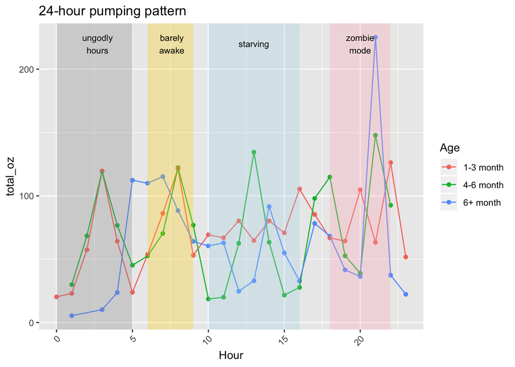

##### As any nursing or pumping mom will tell you, you need frequent sessions to maintain your supply. Hense, the sessions in the middle of the night in the first 6 months …

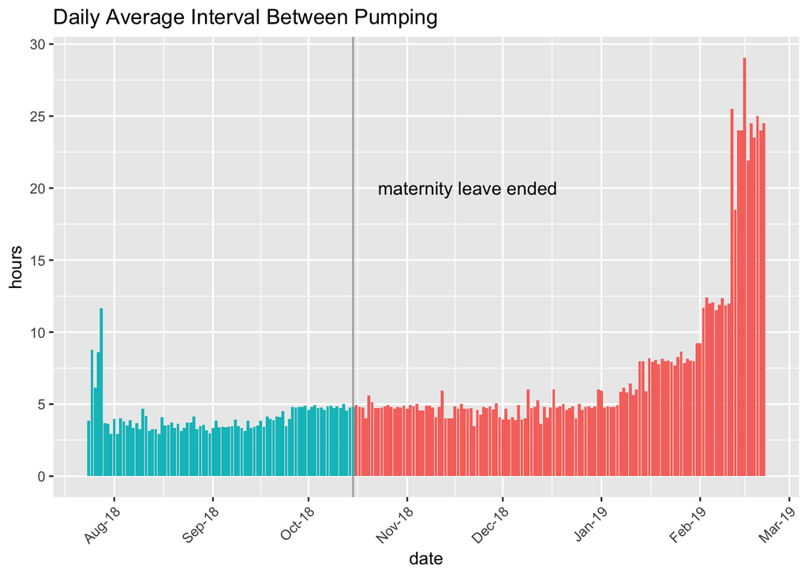

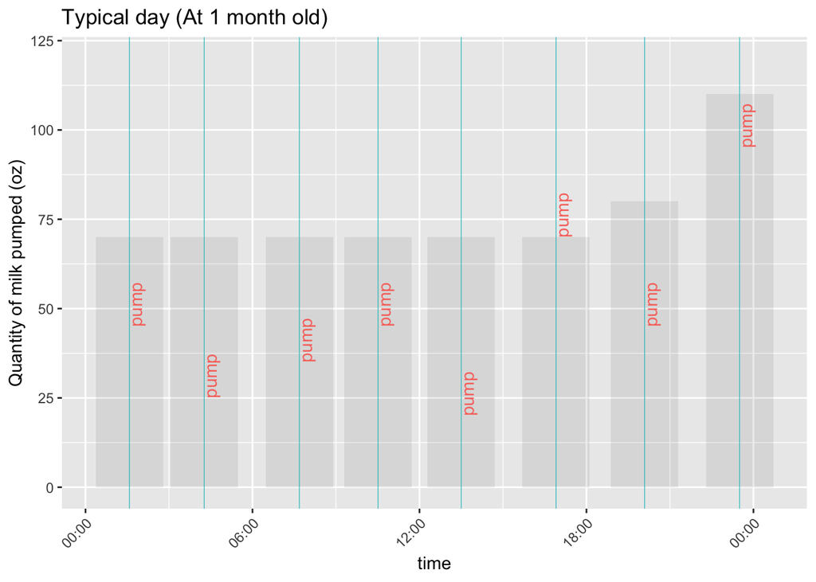

##### But if you layer the feedings…

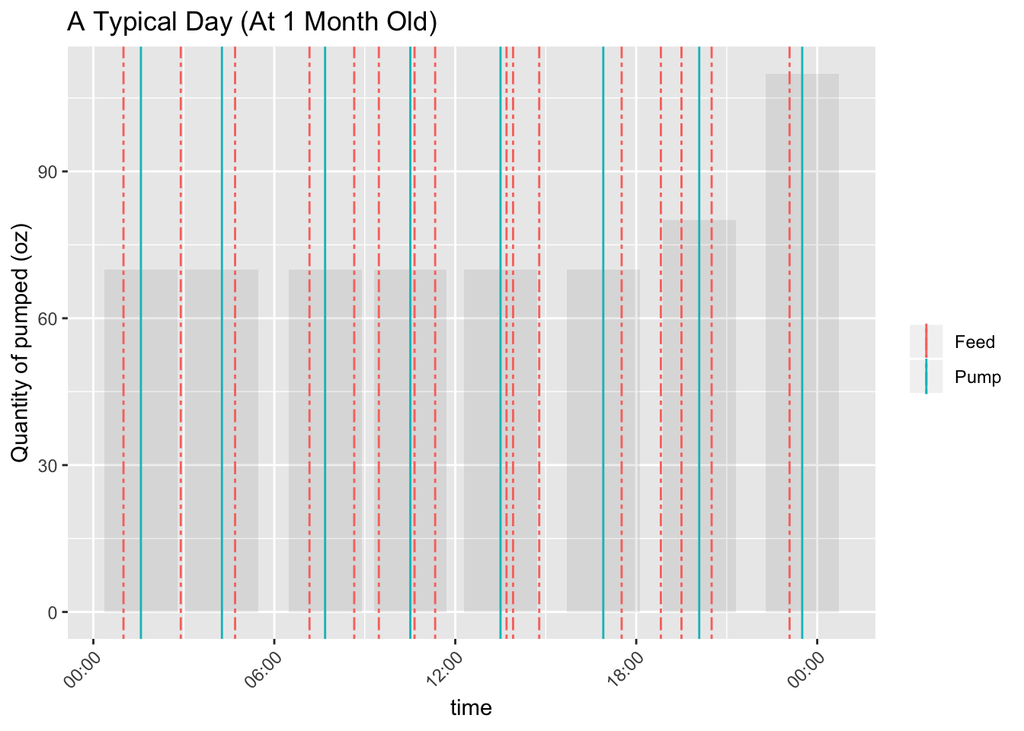

##### … there is really no time to do anything else.

##### As baby gets older …

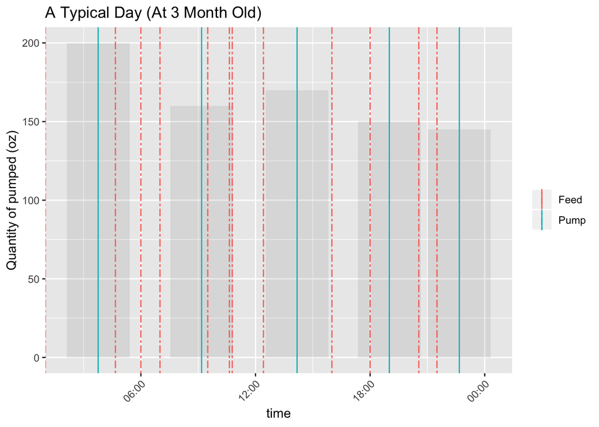

##### Things get less crazy with fewer pumping sessions

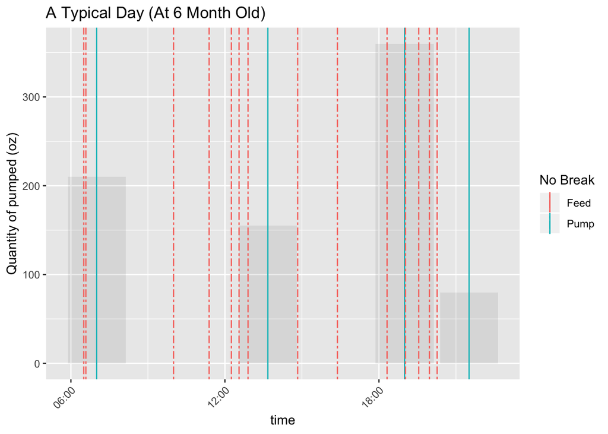

##### Finally, in context of baby’s growth:

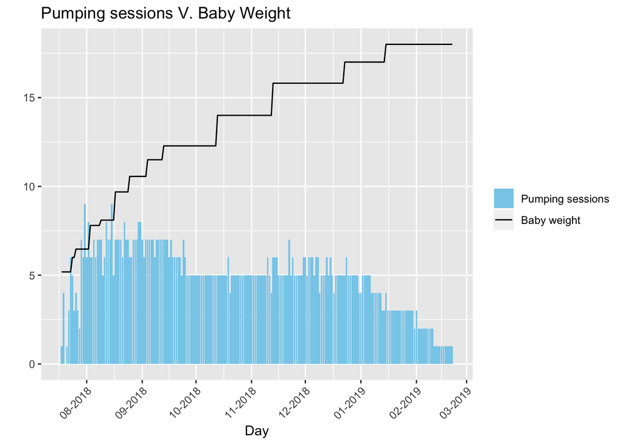

#### Conclusion:

##### Breastfeeding (nursing or pumping) is an incredible amount of work, especially in the first few months after baby’s born. Without support from spouse or family, it is an impossible feat (I have been very lucky to have an awesome husband who does half or more of everything).

##### Returning to work, without a supportive culture, breastfeeding cannot be sustained and motherhood is ten times more difficult than it should be.

##### Kudos to all moms who barely left the house, carried (or have been carrying) a huge sleep debt, followed a restrictive diet, and of course whose breasts have become a war-torn zone. Your baby is one of the luckiest that enjoyed the fruits of your work.

### Happy Mother’s Day (from one mom to all others)!